# EDA 與建模報告：classification_iris.csv

任務：分類（多類別分類（3 類））｜目標：`species`｜產生：2026-10-21 10:52｜遺失值：無｜最佳模型：Random Forest

**150**列數

**4**特徵數（數值 4 / 類別 0）

**無**遺失值

**Random Forest**最佳模型（依 CV）

**0.895**最佳模型測試 Accuracy

## 1. 資料與變數介紹

- **資料說明**：鳶尾花資料集（Fisher, 1936）：150 朵鳶尾花，3 個品種各 50 朵；依花萼與花瓣的長、寬（公分）預測花的品種。
- **分析目的（要預測什麼）**：預測 `species`——鳶尾花品種（預測目標）：setosa（山鳶尾）/ versicolor（變色鳶尾）/ virginica（維吉尼亞鳶尾），共 3 類：setosa（50 筆）、versicolor（50 筆）、virginica（50 筆）。這是一個分類問題（判斷依據見第 2 節）。
- **用了哪些變數**：4 個特徵（數值 4、類別 0）——`sepal_length_cm`（花萼長度，公分）；`sepal_width_cm`（花萼寬度，公分）；`petal_length_cm`（花瓣長度，公分）；`petal_width_cm`（花瓣寬度，公分）。
- 資料共 **150 筆、5 個欄位**：目標 1 個（`species`）、特徵 4 個（數值 4、類別 0）、ID／排除 0 個。
- 沒有 ID 類欄位，所有非目標欄位都當作特徵。
- 完全重複的列 1 筆；常數欄位 無。

### 變數與欄位介紹

| 欄位 | 說明 | 單位 | 角色 | 變數型態 | dtype | 遺失數 |
| --- | --- | --- | --- | --- | --- | --- |
| sepal_length_cm | 花萼長度 | 公分 | 特徵 | 數值 | float64 | 0 |
| sepal_width_cm | 花萼寬度 | 公分 | 特徵 | 數值 | float64 | 0 |
| petal_length_cm | 花瓣長度 | 公分 | 特徵 | 數值 | float64 | 0 |
| petal_width_cm | 花瓣寬度 | 公分 | 特徵 | 數值 | float64 | 0 |
| species | 鳶尾花品種（預測目標）：setosa（山鳶尾）/ versicolor（變色鳶尾）/ virginica（維吉尼亞鳶尾） | — | 目標 | 類別（標籤） | str | 0 |

## 2. 判斷任務類型（分類 or 迴歸）

- **判斷結果：分類（多類別分類（3 類））**。理由：目標是文字／布林值，代表「類別」而非數量。
- 多類別分類 = 預測「屬於哪一類」（超過兩類）；評估用 Accuracy、Macro-F1、混淆矩陣；切分要 stratify 保持各類別比例。
- 判斷規則：文字／布林 → 分類；只有 2 種值 → 二元分類；整數且 ≤10 種值 → 多類別分類（需確認是否為計數/評分）；其餘數值 → 迴歸。任務類型決定了之後的模型（Classifier vs Regressor）、評估指標與切分方式，所以是第一步。

### 任務類型判斷

| 檢查項目 | 結果 |
| --- | --- |
| 目標欄位 | species |
| dtype | str |
| 是否為數值 | 否 |
| 是否全為整數 | 否 |
| 不同值個數 | 3 |
| 不同值佔比 | 2.00% |
| 範例值 | setosa, versicolor, virginica |
| 判斷 | 分類：多類別分類（3 類） |

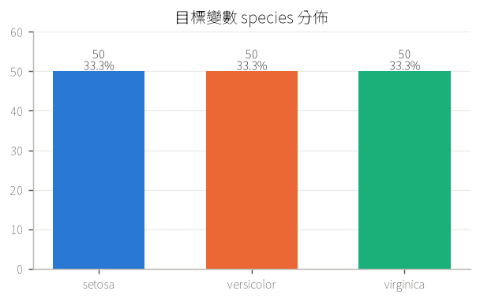

目標變數分佈：分類看各類別比例（是否不平衡）；迴歸看分佈形狀與偏態。

## 3. 敘述性統計

- 目標類別分佈：0=50（33.3%）, 1=50（33.3%）, 2=50（33.3%）。
- 單變量與目標關係最強的特徵：petal_width_cm（η²(H)=0.88）、petal_length_cm（η²(H)=0.87）、sepal_length_cm（η²(H)=0.65）、sepal_width_cm（η²(H)=0.42）。這只是單變量篩選，交互作用與非線性要靠後面的模型。
- 高度相關（|ρ|>0.8）的特徵對共 3 對：petal_length_cm–petal_width_cm（0.94）、sepal_length_cm–petal_length_cm（0.88）、sepal_length_cm–petal_width_cm（0.83）。樹模型預測不受影響，但重要度會被兩者瓜分，解讀時要合併看；它們也是 MICE/KNN 插補的好幫手。

### 數值敘述統計

| 欄位 | 個數 | 遺失% | 平均數 | 標準差 | 最小值 | Q1 | 中位數 | Q3 | 最大值 | IQR | 變異係數CV | 偏態 | 峰態(超額) | 離群值數(1.5IQR) |
| --- | --- | --- | --- | --- | --- | --- | --- | --- | --- | --- | --- | --- | --- | --- |
| sepal_length_cm | 150 | 0 | 5.843 | 0.828 | 4.3 | 5.1 | 5.8 | 6.4 | 7.9 | 1.3 | 0.142 | 0.312 | -0.574 | 0 |
| sepal_width_cm | 150 | 0 | 3.057 | 0.436 | 2 | 2.8 | 3 | 3.3 | 4.4 | 0.5 | 0.143 | 0.316 | 0.181 | 4 |
| petal_length_cm | 150 | 0 | 3.758 | 1.765 | 1 | 1.6 | 4.35 | 5.1 | 6.9 | 3.5 | 0.47 | -0.272 | -1.396 | 0 |
| petal_width_cm | 150 | 0 | 1.199 | 0.762 | 0.1 | 0.3 | 1.3 | 1.8 | 2.5 | 1.5 | 0.636 | -0.102 | -1.336 | 0 |

### 類別敘述統計

| 欄位 | 個數 | 遺失% | 類別數 | 眾數 | 眾數佔比% | 最少類別 | 最少類別佔比% | 各類別次數 |
| --- | --- | --- | --- | --- | --- | --- | --- | --- |
| species | 150 | 0 | 3 | setosa | 33.33 | virginica | 33.33 | setosa=50; versicolor=50; virginica=50 |

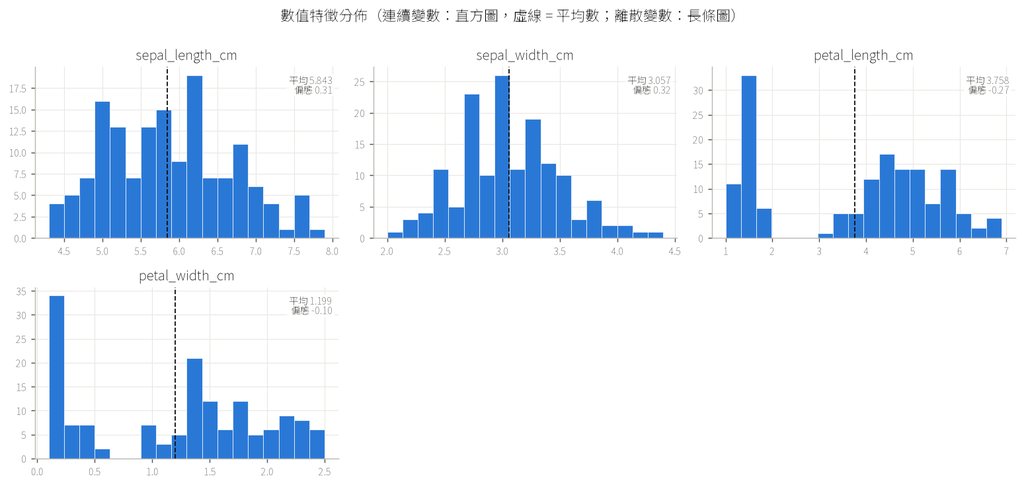

連續變數用直方圖（虛線為平均數），取值少的離散變數（如房間數、車位數）用長條圖；右上角為平均數與偏態。

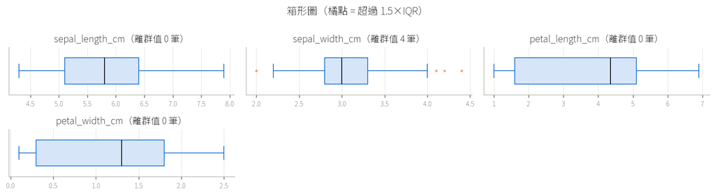

箱形圖：橘點為 1.5×IQR 外的離群值；樹模型對離群值穩健，但明顯的輸入錯誤仍應修正。

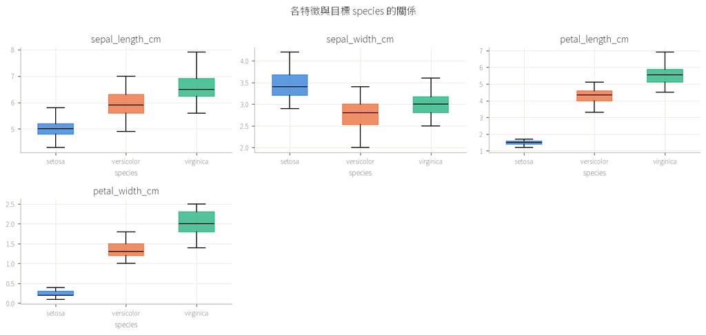

雙變量分析：分類看各類別的分佈差異或各水準的目標比率；迴歸看趨勢與非線性。

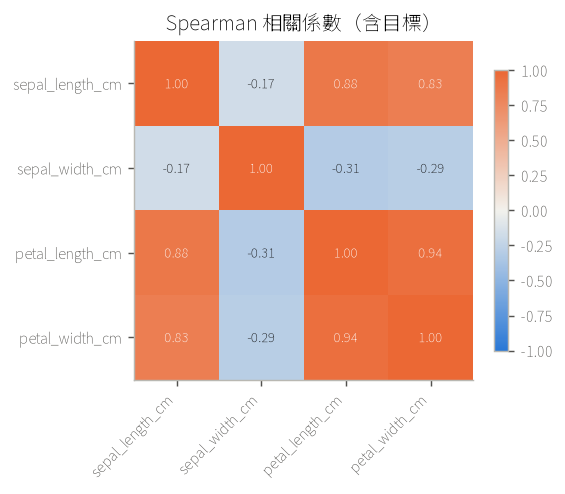

## 4. 遺失值檢查

- **沒有遺失值**：4 個特徵 × 150 筆資料都完整，**不需要做遺失值診斷與插補**，直接進入資料切分與建模。（遺失值的檢查仍必做——上線資料可能出現遺失，屆時再依本 skill 的遺失值流程處理。）

### 遺失值檢查

| 項目 | 結果 |
| --- | --- |
| 特徵欄位數 | 4 |
| 資料筆數 | 150 |
| 總格數 | 600 |
| 遺失格數 | 0（0.00%） |
| 有遺失的欄位數 | 0 |
| 完整列比例 | 100.0% |
| 判斷 | 無遺失 → 跳過遺失值診斷與處理 |

## 5. 資料切分

- **為什麼要切分**：模型在「看過的資料」上的分數一定偏樂觀（尤其是會記住資料的深樹）。必須留一份完全沒碰過的資料，才能估計上線後的真實表現。
- **本次做法**：先切出 25% 測試集（38 筆，鎖起來直到最後），剩下 112 筆訓練集再做 5 折交叉驗證（StratifiedKFold）：每次用 4 折訓練、1 折驗證，輪流 5 次取平均。模型用 CV 分數挑選，測試集只在最後報告一次。
- **分類要 stratify**：讓每份資料的類別比例都和全體相同，否則少數類別可能在某一份裡特別少，分數忽高忽低。
- 切分後各類別筆數（訓練 / 測試）：setosa 38 / 12、versicolor 37 / 13、virginica 37 / 13；合計 112 / 38。各類別在訓練、測試中的比例都和全體一致（stratify 的效果）。
- **避免洩漏**：插補、編碼、特徵選擇都放進 Pipeline，在每一折只用該折的訓練資料 fit；**不要**在切分前對全部資料算平均數補值或標準化。
- **其他切分情境**：有時間順序 → TimeSeriesSplit（只能用過去預測未來）；同一客戶/病人有多筆 → GroupKFold（同一群不能同時出現在訓練與驗證）；Boosting 的 early stopping → 再從訓練集切出一小份驗證集；資料很少 → 用重複 CV（RepeatedKFold）讓估計更穩。

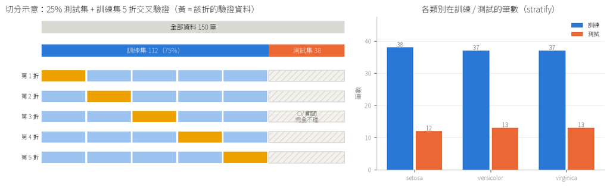

左：切分流程——測試集先鎖起來，訓練集內輪流用其中 1 折當驗證；右：檢查切分後目標分佈是否一致。

### 資料切分（各類別筆數）

| 類別 | 全部筆數 | 訓練筆數 | 測試筆數 | 訓練佔該類% | 測試佔該類% | 訓練集內佔比% | 測試集內佔比% |
| --- | --- | --- | --- | --- | --- | --- | --- |
| setosa | 50 | 38 | 12 | 76 | 24 | 33.9 | 31.6 |
| versicolor | 50 | 37 | 13 | 74 | 26 | 33 | 34.2 |
| virginica | 50 | 37 | 13 | 74 | 26 | 33 | 34.2 |
| 合計 | 150 | 112 | 38 | 74.7 | 25.3 | 100 | 100 |

### 交叉驗證各折

| 折 | 訓練筆數 | 驗證筆數 | 驗證折 setosa 筆數 | 驗證折 versicolor 筆數 | 驗證折 virginica 筆數 |
| --- | --- | --- | --- | --- | --- |
| 1 | 89 | 23 | 8 | 7 | 8 |
| 2 | 89 | 23 | 8 | 7 | 8 |
| 3 | 90 | 22 | 7 | 8 | 7 |
| 4 | 90 | 22 | 7 | 8 | 7 |
| 5 | 90 | 22 | 8 | 7 | 7 |

## 6. 模型訓練與比較（分類）

- 比較三個樹模型：**Decision Tree**（單棵樹，可解釋）、**Random Forest**（多棵深樹平均，降方差）、**Gradient Boosting**（多棵淺樹接力修正殘差，降偏差）。三者使用相同的前處理 Pipeline 與相同的 CV 折，比較才公平。
- **調參方式**：每個樹模型都用 **GridSearchCV** 在訓練集上做 5 折交叉驗證，窮舉「模型參數與調參」表中的參數組合，選 CV Accuracy 最好的一組，再用整個訓練集重新訓練；最後只在測試集評估一次。註：調參後的 CV 分數因為是「挑過的最佳值」而略偏樂觀，所以最終以測試集確認。
- ⚠ 最佳參數落在搜尋範圍的邊界：Gradient Boosting 的 max_depth=2。代表更好的值可能在範圍外，實務上應擴大該參數的搜尋範圍再跑一次。
- 指標（多類別）：Accuracy（整體猜對比例，各類別筆數相同時最直觀，用來調參與選模型）、Macro-F1（各類別 F1 的平均，不受類別多寡影響）、AUC(ovr)（每一類對其他類的排序能力平均）。
- 依 CV 選出最佳模型 **Random Forest**：CV Accuracy 0.964±0.033，測試集 Accuracy 0.895（38 筆猜錯 4 筆）、Macro-F1 0.897。
- 訓練/測試 Accuracy 差距 0.105：有過擬合跡象。
- 測試集只有 38 筆，猜錯 1 筆就差 0.026；多個模型分數接近時應視為平手，不要過度解讀。
- 置換重要度（測試集）前五名：petal_length_cm（0.2210）、petal_width_cm（0.0184）、sepal_width_cm（-0.0237）、sepal_length_cm（-0.0263）。數值 = 打亂該欄後 Accuracy 變差多少；接近 0 或為負的欄位對模型幾乎沒貢獻。重要度不是因果。

### 模型參數與調參

| 模型 | 調參方式 | 搜尋範圍 | 最佳參數 | 固定參數 | 前處理 |
| --- | --- | --- | --- | --- | --- |
| Decision Tree | GridSearchCV（5 折 CV，24 組 × 5 折 = 120 次訓練） | max_depth ∈ [2, 3, 4, 5, 6, 8]；min_samples_leaf ∈ [1, 5, 10, 20] | max_depth=3、min_samples_leaf=1 | criterion=gini、random_state=42 | 數值直接輸入 |
| Random Forest | GridSearchCV（5 折 CV，9 組 × 5 折 = 45 次訓練） | max_features ∈ ['sqrt', 0.5, 1.0]；min_samples_leaf ∈ [1, 3, 5] | max_features=sqrt、min_samples_leaf=1 | n_estimators=300、bootstrap=True、random_state=42 | 數值直接輸入 |
| Gradient Boosting | GridSearchCV（5 折 CV，12 組 × 5 折 = 60 次訓練） | n_estimators ∈ [100, 300]；learning_rate ∈ [0.05, 0.1]；max_depth ∈ [2, 3, 4] | learning_rate=0.05、max_depth=2、n_estimators=100 | subsample=0.8、random_state=42 | 數值直接輸入 |

### 參數說明

| 參數 | 中文 | 意義與影響 |
| --- | --- | --- |
| max_depth | 最大深度 | 樹最多切幾層；越深越能擬合細節，但越容易過擬合（None = 不限制） |
| min_samples_leaf | 葉節點最少樣本數 | 每片葉子至少要有幾筆資料；越大越平滑、越不容易過擬合 |
| max_features | 每次分裂考慮的特徵比例 | RF 每個節點只從隨機抽出的特徵中找切點；越小樹之間越不相關（sqrt = √特徵數） |
| n_estimators | 樹的數量 | 集成中的樹數；RF 越多越穩定，Boosting 太多會過擬合（需搭配學習率） |
| learning_rate | 學習率 η | Boosting 每棵樹的貢獻縮放；越小越穩但需要更多樹 |
| subsample | 列抽樣比例 | 每棵樹只用部分資料訓練（隨機梯度提升），可降低過擬合 |

### 模型比較

| 模型 | 插補 | CV Accuracy | CV Accuracy 標準差 | 訓練 Accuracy | 測試 Accuracy | 測試 Macro-F1 | 測試 AUC(ovr) |
| --- | --- | --- | --- | --- | --- | --- | --- |
| Decision Tree | 無 | 0.9553 | 0.0398 | 0.9643 | 0.8947 | 0.8968 | 0.9774 |
| Random Forest | 無 | 0.9644 | 0.0328 | 1 | 0.8947 | 0.8968 | 0.9887 |
| Gradient Boosting | 無 | 0.9557 | 0.0275 | 1 | 0.9211 | 0.923 | 0.9918 |

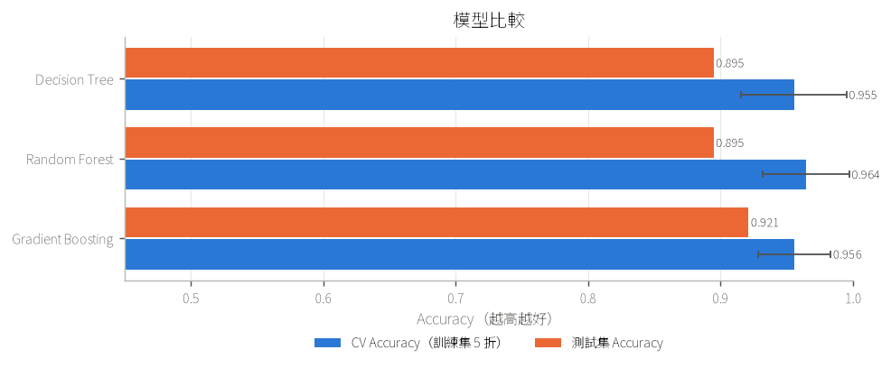

以 CV 選模型、測試集只做最終確認；誤差棒為 CV 標準差。

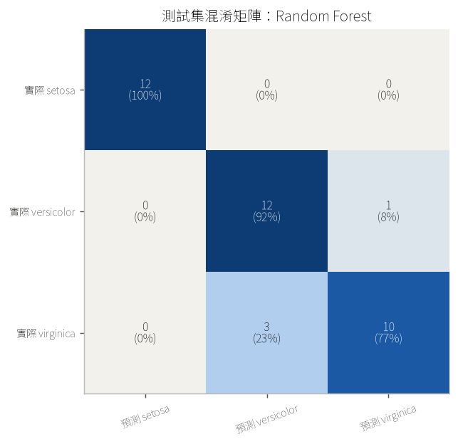

對角線 = 猜對；括號為該實際類別中被預測成各類的比例（每列加總 100%），可看出哪兩類容易混淆。

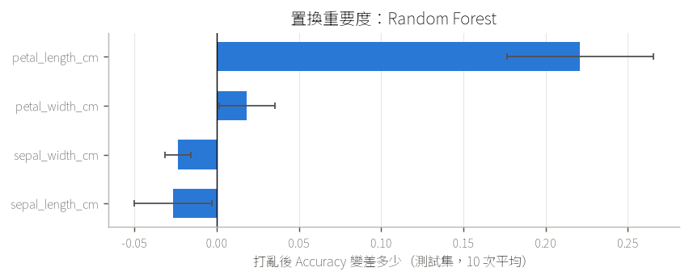

以原始欄位為單位計算（one-hot 與遺失指標一起算），比 impurity 重要度更不易被高基數 / 雜訊欄位騙。

所有表格另存於 descriptive_stats.xlsx；圖檔在 figures/。